# Risk Factor Analysis

## Outcome Variable

**Outcome Variable:** y_rate_haz

## Predictor Variables

**Intervention Variable:** hfoodsec

**Adjustment Set:**

- arm
- sex
- W_mage
- meducyrs
- feducyrs
- hhwealth_quart
- vagbrth
- W_nrooms
- W_nchldlt5
- brthmon
- W_parity
- impfloor
- impsan
- safeh20
- delta_W_mage
- delta_meducyrs
- delta_feducyrs
- delta_hhwealth_quart
- delta_vagbrth
- delta_W_nrooms
- delta_W_nchldlt5
- delta_brthmon
- delta_W_parity
- delta_impfloor
- delta_impsan
- delta_safeh20

## Stratifying Variables

The analysis was stratified on these variable(s):

- agecat
- studyid
- country

## Data Summary

| agecat | studyid | country | hfoodsec | n_cell | n |
| --- | --- | --- | --- | --- | --- |
| 0-3 months | ki0047075b-MAL-ED | BANGLADESH | Food Secure | 160 | 192 |
| 0-3 months | ki0047075b-MAL-ED | BANGLADESH | Mildly Food Insecure | 4 | 192 |
| 0-3 months | ki0047075b-MAL-ED | BANGLADESH | Moderately Food Insecure | 22 | 192 |
| 0-3 months | ki0047075b-MAL-ED | BANGLADESH | Severely Food Insecure | 6 | 192 |
| 0-3 months | ki1017093-NIH-Birth | BANGLADESH | Food Secure | 83 | 566 |
| 0-3 months | ki1017093-NIH-Birth | BANGLADESH | Mildly Food Insecure | 444 | 566 |
| 0-3 months | ki1017093-NIH-Birth | BANGLADESH | Moderately Food Insecure | 34 | 566 |
| 0-3 months | ki1017093-NIH-Birth | BANGLADESH | Severely Food Insecure | 5 | 566 |
| 0-3 months | ki1017093c-NIH-Crypto | BANGLADESH | Food Secure | 427 | 720 |
| 0-3 months | ki1017093c-NIH-Crypto | BANGLADESH | Mildly Food Insecure | 207 | 720 |
| 0-3 months | ki1017093c-NIH-Crypto | BANGLADESH | Moderately Food Insecure | 62 | 720 |
| 0-3 months | ki1017093c-NIH-Crypto | BANGLADESH | Severely Food Insecure | 24 | 720 |
| 0-3 months | kiGH5241-JiVitA-3 | BANGLADESH | Food Secure | 6496 | 13158 |
| 0-3 months | kiGH5241-JiVitA-3 | BANGLADESH | Mildly Food Insecure | 4424 | 13158 |
| 0-3 months | kiGH5241-JiVitA-3 | BANGLADESH | Moderately Food Insecure | 2238 | 13158 |
| 0-3 months | kiGH5241-JiVitA-4 | BANGLADESH | Food Secure | 914 | 1796 |
| 0-3 months | kiGH5241-JiVitA-4 | BANGLADESH | Mildly Food Insecure | 634 | 1796 |
| 0-3 months | kiGH5241-JiVitA-4 | BANGLADESH | Moderately Food Insecure | 248 | 1796 |
| 0-3 months | ki0047075b-MAL-ED | BRAZIL | Mildly Food Insecure | 11 | 105 |
| 0-3 months | ki0047075b-MAL-ED | BRAZIL | Moderately Food Insecure | 54 | 105 |
| 0-3 months | ki0047075b-MAL-ED | BRAZIL | Severely Food Insecure | 40 | 105 |
| 0-3 months | ki0047075b-MAL-ED | INDIA | Food Secure | 157 | 173 |
| 0-3 months | ki0047075b-MAL-ED | INDIA | Mildly Food Insecure | 2 | 173 |
| 0-3 months | ki0047075b-MAL-ED | INDIA | Moderately Food Insecure | 3 | 173 |
| 0-3 months | ki0047075b-MAL-ED | INDIA | Severely Food Insecure | 11 | 173 |
| 0-3 months | ki0047075b-MAL-ED | NEPAL | Food Secure | 77 | 100 |
| 0-3 months | ki0047075b-MAL-ED | NEPAL | Mildly Food Insecure | 9 | 100 |
| 0-3 months | ki0047075b-MAL-ED | NEPAL | Moderately Food Insecure | 11 | 100 |
| 0-3 months | ki0047075b-MAL-ED | NEPAL | Severely Food Insecure | 3 | 100 |
| 0-3 months | ki0047075b-MAL-ED | PERU | Food Secure | 27 | 107 |

[output cut: 133 more lines]

The following strata were considered:

- agecat: 0-3 months, studyid: ki0047075b-MAL-ED, country: BANGLADESH
- agecat: 0-3 months, studyid: ki0047075b-MAL-ED, country: BRAZIL
- agecat: 0-3 months, studyid: ki0047075b-MAL-ED, country: INDIA
- agecat: 0-3 months, studyid: ki0047075b-MAL-ED, country: NEPAL
- agecat: 0-3 months, studyid: ki0047075b-MAL-ED, country: PERU
- agecat: 0-3 months, studyid: ki0047075b-MAL-ED, country: SOUTH AFRICA
- agecat: 0-3 months, studyid: ki1017093-NIH-Birth, country: BANGLADESH
- agecat: 0-3 months, studyid: ki1017093c-NIH-Crypto, country: BANGLADESH
- agecat: 0-3 months, studyid: kiGH5241-JiVitA-3, country: BANGLADESH
- agecat: 0-3 months, studyid: kiGH5241-JiVitA-4, country: BANGLADESH
- agecat: 12-24 months, studyid: ki0047075b-MAL-ED, country: BANGLADESH
- agecat: 12-24 months, studyid: ki0047075b-MAL-ED, country: BRAZIL
- agecat: 12-24 months, studyid: ki0047075b-MAL-ED, country: INDIA
- agecat: 12-24 months, studyid: ki0047075b-MAL-ED, country: NEPAL
- agecat: 12-24 months, studyid: ki0047075b-MAL-ED, country: PERU
- agecat: 12-24 months, studyid: ki0047075b-MAL-ED, country: SOUTH AFRICA
- agecat: 12-24 months, studyid: ki1017093-NIH-Birth, country: BANGLADESH
- agecat: 12-24 months, studyid: ki1017093c-NIH-Crypto, country: BANGLADESH
- agecat: 12-24 months, studyid: ki1113344-GMS-Nepal, country: NEPAL
- agecat: 12-24 months, studyid: kiGH5241-JiVitA-3, country: BANGLADESH
- agecat: 12-24 months, studyid: kiGH5241-JiVitA-4, country: BANGLADESH
- agecat: 3-6 months, studyid: ki0047075b-MAL-ED, country: BANGLADESH
- agecat: 3-6 months, studyid: ki0047075b-MAL-ED, country: BRAZIL
- agecat: 3-6 months, studyid: ki0047075b-MAL-ED, country: INDIA
- agecat: 3-6 months, studyid: ki0047075b-MAL-ED, country: NEPAL
- agecat: 3-6 months, studyid: ki0047075b-MAL-ED, country: PERU
- agecat: 3-6 months, studyid: ki0047075b-MAL-ED, country: SOUTH AFRICA
- agecat: 3-6 months, studyid: ki1017093-NIH-Birth, country: BANGLADESH
- agecat: 3-6 months, studyid: ki1017093c-NIH-Crypto, country: BANGLADESH
- agecat: 3-6 months, studyid: ki1113344-GMS-Nepal, country: NEPAL
- agecat: 3-6 months, studyid: kiGH5241-JiVitA-3, country: BANGLADESH
- agecat: 3-6 months, studyid: kiGH5241-JiVitA-4, country: BANGLADESH
- agecat: 6-12 months, studyid: ki0047075b-MAL-ED, country: BANGLADESH
- agecat: 6-12 months, studyid: ki0047075b-MAL-ED, country: BRAZIL
- agecat: 6-12 months, studyid: ki0047075b-MAL-ED, country: INDIA
- agecat: 6-12 months, studyid: ki0047075b-MAL-ED, country: NEPAL
- agecat: 6-12 months, studyid: ki0047075b-MAL-ED, country: PERU
- agecat: 6-12 months, studyid: ki0047075b-MAL-ED, country: SOUTH AFRICA
- agecat: 6-12 months, studyid: ki1017093-NIH-Birth, country: BANGLADESH
- agecat: 6-12 months, studyid: ki1017093c-NIH-Crypto, country: BANGLADESH
- agecat: 6-12 months, studyid: ki1113344-GMS-Nepal, country: NEPAL
- agecat: 6-12 months, studyid: kiGH5241-JiVitA-3, country: BANGLADESH
- agecat: 6-12 months, studyid: kiGH5241-JiVitA-4, country: BANGLADESH

### Dropped Strata

Some strata were dropped due to rare outcomes:

- agecat: 0-3 months, studyid: ki0047075b-MAL-ED, country: BANGLADESH
- agecat: 0-3 months, studyid: ki0047075b-MAL-ED, country: INDIA
- agecat: 0-3 months, studyid: ki0047075b-MAL-ED, country: NEPAL
- agecat: 3-6 months, studyid: ki0047075b-MAL-ED, country: BANGLADESH
- agecat: 3-6 months, studyid: ki1017093-NIH-Birth, country: BANGLADESH
- agecat: 3-6 months, studyid: ki0047075b-MAL-ED, country: BRAZIL
- agecat: 3-6 months, studyid: ki0047075b-MAL-ED, country: INDIA
- agecat: 3-6 months, studyid: ki0047075b-MAL-ED, country: NEPAL
- agecat: 6-12 months, studyid: ki0047075b-MAL-ED, country: BANGLADESH
- agecat: 6-12 months, studyid: ki1017093-NIH-Birth, country: BANGLADESH
- agecat: 6-12 months, studyid: ki0047075b-MAL-ED, country: BRAZIL
- agecat: 6-12 months, studyid: ki0047075b-MAL-ED, country: INDIA
- agecat: 6-12 months, studyid: ki0047075b-MAL-ED, country: NEPAL
- agecat: 12-24 months, studyid: ki0047075b-MAL-ED, country: BANGLADESH
- agecat: 12-24 months, studyid: ki1017093-NIH-Birth, country: BANGLADESH
- agecat: 12-24 months, studyid: ki0047075b-MAL-ED, country: BRAZIL
- agecat: 12-24 months, studyid: ki0047075b-MAL-ED, country: INDIA
- agecat: 12-24 months, studyid: ki0047075b-MAL-ED, country: NEPAL

## Methods Detail

We’re interested in the causal parameters $E[Y_a]$ for all values of $a \in \mathcal{A}$. These parameters represent the mean outcome if, possibly contrary to fact, we intervened to set all units to have $A=a$. Under the randomization and positivity assumptions, these are identified by the statistical parameters $\psi_a=E_W[E_{Y|A,W}(Y|A=a,W)]$. In addition, we’re interested in the mean of $Y$, $E[Y]$ under no intervention (the observed mean). We will estimate these parameters by using SuperLearner to fit the relevant likelihood factors – $E_{Y|A,W}(Y|A=a,W)$ and $p(A=a|W)$, and then updating our likelihood fit using a joint TMLE.

For unadjusted analyses ($W=\{\}$), initial likelihoods were estimated using Lrnr_glm to estimate the simple $E(Y|A)$ and Lrnr_mean to estimate $p(A)$. For adjusted analyses, a small library containing Lrnr_glmnet, Lrnr_xgboost, and Lrnr_mean was used.

Having estimated these parameters, we will then use the delta method to estimate relative risks and attributable risks relative to a prespecified baseline level of $A$.

[output not shown]

[output not shown]

[output not shown]

[output not shown]

[output not shown]

[output not shown]

[output not shown]

[output not shown]

[output not shown]

# Results Detail

## Results Plots

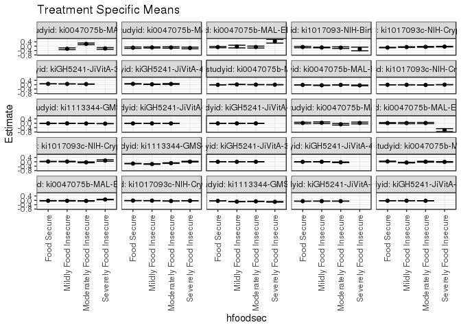

[figure not shown]

## Results Table

### Parameter: TSM

| agecat | studyid | country | intervention_level | baseline_level | estimate | ci_lower | ci_upper |
| --- | --- | --- | --- | --- | --- | --- | --- |
| 0-3 months | ki0047075b-MAL-ED | BRAZIL | Mildly Food Insecure | NA | -0.2386074 | -0.3214115 | -0.1558032 |
| 0-3 months | ki0047075b-MAL-ED | BRAZIL | Moderately Food Insecure | NA | 0.2076528 | 0.1308440 | 0.2844615 |
| 0-3 months | ki0047075b-MAL-ED | BRAZIL | Severely Food Insecure | NA | -0.2111783 | -0.2910280 | -0.1313286 |
| 0-3 months | ki0047075b-MAL-ED | PERU | Food Secure | NA | -0.1418593 | -0.2063175 | -0.0774012 |
| 0-3 months | ki0047075b-MAL-ED | PERU | Mildly Food Insecure | NA | -0.1213162 | -0.1722751 | -0.0703572 |
| 0-3 months | ki0047075b-MAL-ED | PERU | Moderately Food Insecure | NA | -0.1268193 | -0.1912514 | -0.0623872 |
| 0-3 months | ki0047075b-MAL-ED | PERU | Severely Food Insecure | NA | -0.1668049 | -0.2396734 | -0.0939364 |
| 0-3 months | ki0047075b-MAL-ED | SOUTH AFRICA | Food Secure | NA | -0.0860278 | -0.1447319 | -0.0273237 |
| 0-3 months | ki0047075b-MAL-ED | SOUTH AFRICA | Mildly Food Insecure | NA | -0.0367476 | -0.1592227 | 0.0857275 |
| 0-3 months | ki0047075b-MAL-ED | SOUTH AFRICA | Moderately Food Insecure | NA | -0.0826453 | -0.1677846 | 0.0024940 |
| 0-3 months | ki0047075b-MAL-ED | SOUTH AFRICA | Severely Food Insecure | NA | 0.4512612 | 0.2788638 | 0.6236587 |
| 0-3 months | ki1017093-NIH-Birth | BANGLADESH | Food Secure | NA | -0.0817283 | -0.1436026 | -0.0198539 |
| 0-3 months | ki1017093-NIH-Birth | BANGLADESH | Mildly Food Insecure | NA | -0.1236376 | -0.1541234 | -0.0931518 |
| 0-3 months | ki1017093-NIH-Birth | BANGLADESH | Moderately Food Insecure | NA | -0.1390658 | -0.2104242 | -0.0677075 |
| 0-3 months | ki1017093-NIH-Birth | BANGLADESH | Severely Food Insecure | NA | -0.2562976 | -0.4231771 | -0.0894181 |
| 0-3 months | ki1017093c-NIH-Crypto | BANGLADESH | Food Secure | NA | -0.1285735 | -0.1514928 | -0.1056541 |
| 0-3 months | ki1017093c-NIH-Crypto | BANGLADESH | Mildly Food Insecure | NA | -0.0852488 | -0.1151328 | -0.0553647 |
| 0-3 months | ki1017093c-NIH-Crypto | BANGLADESH | Moderately Food Insecure | NA | -0.0656915 | -0.1022541 | -0.0291290 |
| 0-3 months | ki1017093c-NIH-Crypto | BANGLADESH | Severely Food Insecure | NA | -0.0427395 | -0.0707094 | -0.0147696 |
| 0-3 months | kiGH5241-JiVitA-3 | BANGLADESH | Food Secure | NA | 0.0781367 | 0.0707760 | 0.0854974 |
| 0-3 months | kiGH5241-JiVitA-3 | BANGLADESH | Mildly Food Insecure | NA | 0.0694648 | 0.0605785 | 0.0783510 |
| 0-3 months | kiGH5241-JiVitA-3 | BANGLADESH | Moderately Food Insecure | NA | 0.0549189 | 0.0410942 | 0.0687437 |
| 0-3 months | kiGH5241-JiVitA-4 | BANGLADESH | Food Secure | NA | 0.0756126 | 0.0532918 | 0.0979334 |
| 0-3 months | kiGH5241-JiVitA-4 | BANGLADESH | Mildly Food Insecure | NA | 0.0385521 | 0.0145305 | 0.0625737 |
| 0-3 months | kiGH5241-JiVitA-4 | BANGLADESH | Moderately Food Insecure | NA | 0.0671983 | 0.0273503 | 0.1070462 |
| 3-6 months | ki0047075b-MAL-ED | PERU | Food Secure | NA | 0.0222185 | -0.0432332 | 0.0876702 |
| 3-6 months | ki0047075b-MAL-ED | PERU | Mildly Food Insecure | NA | 0.0402170 | -0.0369498 | 0.1173839 |
| 3-6 months | ki0047075b-MAL-ED | PERU | Moderately Food Insecure | NA | -0.0954451 | -0.1669954 | -0.0238949 |
| 3-6 months | ki0047075b-MAL-ED | PERU | Severely Food Insecure | NA | 0.0227061 | -0.0573890 | 0.1028012 |
| 3-6 months | ki0047075b-MAL-ED | SOUTH AFRICA | Food Secure | NA | 0.0146613 | -0.0332227 | 0.0625454 |

[output cut: 61 more lines]

### Parameter: E(Y)

| agecat | studyid | country | intervention_level | baseline_level | estimate | ci_lower | ci_upper |
| --- | --- | --- | --- | --- | --- | --- | --- |
| 0-3 months | ki0047075b-MAL-ED | BRAZIL | NA | NA | 0.1741611 | 0.1064061 | 0.2419161 |
| 0-3 months | ki0047075b-MAL-ED | PERU | NA | NA | -0.1456660 | -0.1918985 | -0.0994335 |
| 0-3 months | ki0047075b-MAL-ED | SOUTH AFRICA | NA | NA | -0.1060062 | -0.1537996 | -0.0582128 |
| 0-3 months | ki1017093-NIH-Birth | BANGLADESH | NA | NA | -0.1191165 | -0.1460676 | -0.0921654 |
| 0-3 months | ki1017093c-NIH-Crypto | BANGLADESH | NA | NA | -0.1220821 | -0.1402761 | -0.1038881 |
| 0-3 months | kiGH5241-JiVitA-3 | BANGLADESH | NA | NA | 0.0720811 | 0.0664392 | 0.0777230 |
| 0-3 months | kiGH5241-JiVitA-4 | BANGLADESH | NA | NA | 0.0679445 | 0.0527205 | 0.0831684 |
| 3-6 months | ki0047075b-MAL-ED | PERU | NA | NA | -0.0044217 | -0.0515604 | 0.0427170 |
| 3-6 months | ki0047075b-MAL-ED | SOUTH AFRICA | NA | NA | -0.0040696 | -0.0441194 | 0.0359801 |
| 3-6 months | ki1017093c-NIH-Crypto | BANGLADESH | NA | NA | 0.0267740 | 0.0099602 | 0.0435879 |
| 3-6 months | ki1113344-GMS-Nepal | NEPAL | NA | NA | -0.1659597 | -0.1846663 | -0.1472532 |
| 3-6 months | kiGH5241-JiVitA-3 | BANGLADESH | NA | NA | -0.0034833 | -0.0083476 | 0.0013811 |
| 3-6 months | kiGH5241-JiVitA-4 | BANGLADESH | NA | NA | -0.0085546 | -0.0222850 | 0.0051757 |
| 6-12 months | ki0047075b-MAL-ED | PERU | NA | NA | -0.0482152 | -0.0696362 | -0.0267942 |
| 6-12 months | ki0047075b-MAL-ED | SOUTH AFRICA | NA | NA | -0.0519712 | -0.0699293 | -0.0340130 |
| 6-12 months | ki1017093c-NIH-Crypto | BANGLADESH | NA | NA | -0.0315658 | -0.0388594 | -0.0242722 |
| 6-12 months | ki1113344-GMS-Nepal | NEPAL | NA | NA | -0.0598718 | -0.0680985 | -0.0516452 |
| 6-12 months | kiGH5241-JiVitA-3 | BANGLADESH | NA | NA | -0.0748352 | -0.0776789 | -0.0719915 |
| 6-12 months | kiGH5241-JiVitA-4 | BANGLADESH | NA | NA | -0.0384218 | -0.0427729 | -0.0340708 |
| 12-24 months | ki0047075b-MAL-ED | PERU | NA | NA | 0.0010141 | -0.0093609 | 0.0113891 |
| 12-24 months | ki0047075b-MAL-ED | SOUTH AFRICA | NA | NA | -0.0149856 | -0.0226448 | -0.0073265 |
| 12-24 months | ki1017093c-NIH-Crypto | BANGLADESH | NA | NA | -0.0057326 | -0.0097260 | -0.0017391 |
| 12-24 months | ki1113344-GMS-Nepal | NEPAL | NA | NA | -0.0153024 | -0.0203628 | -0.0102420 |
| 12-24 months | kiGH5241-JiVitA-3 | BANGLADESH | NA | NA | -0.0187407 | -0.0205876 | -0.0168938 |
| 12-24 months | kiGH5241-JiVitA-4 | BANGLADESH | NA | NA | -0.0144593 | -0.0163257 | -0.0125930 |

### Parameter: ATE

| agecat | studyid | country | intervention_level | baseline_level | estimate | ci_lower | ci_upper |
| --- | --- | --- | --- | --- | --- | --- | --- |
| 0-3 months | ki0047075b-MAL-ED | BRAZIL | Mildly Food Insecure | Mildly Food Insecure | 0.0000000 | 0.0000000 | 0.0000000 |
| 0-3 months | ki0047075b-MAL-ED | BRAZIL | Moderately Food Insecure | Mildly Food Insecure | 0.4462602 | 0.3347437 | 0.5577767 |
| 0-3 months | ki0047075b-MAL-ED | BRAZIL | Severely Food Insecure | Mildly Food Insecure | 0.0274291 | -0.0879918 | 0.1428500 |
| 0-3 months | ki0047075b-MAL-ED | PERU | Food Secure | Food Secure | 0.0000000 | 0.0000000 | 0.0000000 |
| 0-3 months | ki0047075b-MAL-ED | PERU | Mildly Food Insecure | Food Secure | 0.0205432 | -0.0495796 | 0.0906660 |
| 0-3 months | ki0047075b-MAL-ED | PERU | Moderately Food Insecure | Food Secure | 0.0150401 | -0.0688590 | 0.0989392 |
| 0-3 months | ki0047075b-MAL-ED | PERU | Severely Food Insecure | Food Secure | -0.0249456 | -0.1071968 | 0.0573057 |
| 0-3 months | ki0047075b-MAL-ED | SOUTH AFRICA | Food Secure | Food Secure | 0.0000000 | 0.0000000 | 0.0000000 |
| 0-3 months | ki0047075b-MAL-ED | SOUTH AFRICA | Mildly Food Insecure | Food Secure | 0.0492802 | -0.0864094 | 0.1849698 |
| 0-3 months | ki0047075b-MAL-ED | SOUTH AFRICA | Moderately Food Insecure | Food Secure | 0.0033825 | -0.0999190 | 0.1066840 |
| 0-3 months | ki0047075b-MAL-ED | SOUTH AFRICA | Severely Food Insecure | Food Secure | 0.5372891 | 0.3552243 | 0.7193538 |
| 0-3 months | ki1017093-NIH-Birth | BANGLADESH | Food Secure | Food Secure | 0.0000000 | 0.0000000 | 0.0000000 |
| 0-3 months | ki1017093-NIH-Birth | BANGLADESH | Mildly Food Insecure | Food Secure | -0.0419093 | -0.1105991 | 0.0267806 |
| 0-3 months | ki1017093-NIH-Birth | BANGLADESH | Moderately Food Insecure | Food Secure | -0.0573375 | -0.1515218 | 0.0368467 |
| 0-3 months | ki1017093-NIH-Birth | BANGLADESH | Severely Food Insecure | Food Secure | -0.1745693 | -0.3521969 | 0.0030583 |
| 0-3 months | ki1017093c-NIH-Crypto | BANGLADESH | Food Secure | Food Secure | 0.0000000 | 0.0000000 | 0.0000000 |
| 0-3 months | ki1017093c-NIH-Crypto | BANGLADESH | Mildly Food Insecure | Food Secure | 0.0433247 | 0.0061861 | 0.0804633 |
| 0-3 months | ki1017093c-NIH-Crypto | BANGLADESH | Moderately Food Insecure | Food Secure | 0.0628819 | 0.0201949 | 0.1055689 |
| 0-3 months | ki1017093c-NIH-Crypto | BANGLADESH | Severely Food Insecure | Food Secure | 0.0858340 | 0.0501920 | 0.1214759 |
| 0-3 months | kiGH5241-JiVitA-3 | BANGLADESH | Food Secure | Food Secure | 0.0000000 | 0.0000000 | 0.0000000 |
| 0-3 months | kiGH5241-JiVitA-3 | BANGLADESH | Mildly Food Insecure | Food Secure | -0.0086719 | -0.0199241 | 0.0025802 |
| 0-3 months | kiGH5241-JiVitA-3 | BANGLADESH | Moderately Food Insecure | Food Secure | -0.0232178 | -0.0380555 | -0.0083801 |
| 0-3 months | kiGH5241-JiVitA-4 | BANGLADESH | Food Secure | Food Secure | 0.0000000 | 0.0000000 | 0.0000000 |
| 0-3 months | kiGH5241-JiVitA-4 | BANGLADESH | Mildly Food Insecure | Food Secure | -0.0370605 | -0.0706397 | -0.0034813 |
| 0-3 months | kiGH5241-JiVitA-4 | BANGLADESH | Moderately Food Insecure | Food Secure | -0.0084143 | -0.0540483 | 0.0372196 |
| 3-6 months | ki0047075b-MAL-ED | PERU | Food Secure | Food Secure | 0.0000000 | 0.0000000 | 0.0000000 |
| 3-6 months | ki0047075b-MAL-ED | PERU | Mildly Food Insecure | Food Secure | 0.0179985 | -0.0782617 | 0.1142588 |
| 3-6 months | ki0047075b-MAL-ED | PERU | Moderately Food Insecure | Food Secure | -0.1176636 | -0.2134948 | -0.0218324 |
| 3-6 months | ki0047075b-MAL-ED | PERU | Severely Food Insecure | Food Secure | 0.0004876 | -0.1007049 | 0.1016801 |
| 3-6 months | ki0047075b-MAL-ED | SOUTH AFRICA | Food Secure | Food Secure | 0.0000000 | 0.0000000 | 0.0000000 |

[output cut: 61 more lines]